# Chapter 12: Interaction Effects

## Introduction to Interactions in Linear Models

### What is an Interaction?

An **interaction** occurs when the effect of one predictor variable on an outcome variable changes depending on the level of another predictor variable. Interactions are common in the real world, where combined factors often influence outcomes differently than when considered alone.

- **Example**: In a study of **exercise** and **stress levels** on **mood**, exercise might improve mood more for people with high stress than for those with low stress. Here, stress level moderates the effect of exercise on mood.

### Main Effects vs. Interaction Effects

- **Main Effect**: The **main effect** of a predictor shows its average influence on the outcome, ignoring other predictors.
  - **Example**: The main effect of **diet** on **energy levels** would show how diet affects energy on average, without considering other factors like sleep quality.
- **Interaction Effect**: An **interaction effect** occurs when the effect of one predictor depends on the level of another predictor.
  - **Example**: If diet quality has a stronger effect on energy when sleep quality is high than when it is low, there is an interaction effect between diet and sleep.

## Using Means to Understand Interactions

- **Overall Mean**: Represents the average outcome across all predictor combinations.
- **Group Means**: Group means are the averages for specific predictor combinations (e.g., diet and sleep levels).

  **Example**: If we examine diet (high vs. low) and sleep (high vs. low) on energy:
  - Group means would be calculated separately for high-diet/high-sleep, low-diet/low-sleep, etc.
  - If the effect of diet on energy varies by sleep quality (e.g., stronger for high sleep), an interaction is present.

  By comparing group means, we can detect interactions:
  - **Cross-over interaction**: Group means show opposite effects (e.g., diet improves energy under high sleep but reduces it under low sleep).
  - **Magnitude interaction**: Group means show different effect sizes without changing direction (e.g., diet improves energy more under high sleep but still improves under low sleep).

## Types of Interactions: Cross-Over vs. Magnitude

1. **Cross-Over Interaction**: Occurs when the effect of one predictor reverses at different levels of another predictor.
   - **Example**: Suppose **therapy** reduces stress for adults but increases stress for teens due to peer pressure.
2. **Magnitude Interaction**: Occurs when the effect of one predictor is stronger or weaker at different levels of another predictor, but the direction remains the same.
   - **Example**: Exercise improves mood more for high-stress individuals than low-stress ones, but it improves mood in both cases.

## Setting Up an Interaction in R

To set up an interaction term in a linear model in R, we use the `*` operator. Here’s an example with simulated data for **sleep quality** and **stress level** predicting **productivity**.

```r
# sleep_code "High" = 1, "Low" = -1
# stress_code = "High" = 1, "Low" = -1)
model <- lm(productivity ~ sleep_code * stress_code, data = dataset)
```

| Sleep Quality | Stress Level | Mean Productivity |
| --- | --- | --- |
| High | High | 89.90001 |
| High | Low | 50.30641 |
| Low | High | 55.03072 |
| Low | Low | 85.84773 |

Regression Results for Productivity Predicted by Sleep and Stress Levels

Productivity

Predictors

Estimates

std. Error

Statistic

(Intercept)

70.27 ***

0.28

254.97

Sleep Code

-0.17

0.28

-0.61

Stress Code

2.19 ***

0.28

7.96

Sleep Code * Stress Code

17.60 ***

0.28

63.87

Observations

100

R<sup>2</sup> / R<sup>2</sup> adjusted

0.977 / 0.977

- p<0.05 ** p<0.01 *** p<0.001

## Visualizing Interactions with Interaction Plots

Visualizing interactions helps reveal patterns. Here’s how to use `ggplot2` to create an interaction plot for the **sleep quality** and **stress level** example, with error bars.

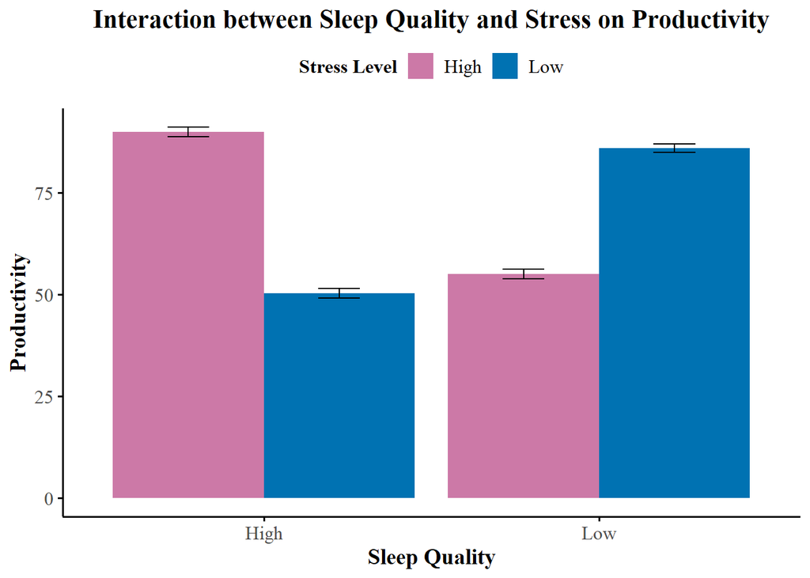

- **Interpreting the Plot**:
  - Cross-over interactions show lines crossing, meaning one predictor reverses the effect of the other.
  - Magnitude interactions show different slopes without crossing, indicating the effect size changes but the direction remains the same.

## Simulating Data for Specific Interactions

### 1. Simulating a Magnitude Interaction

In this example, both **hours studied** and **sleep quality** impact **exam scores**, but the effect of hours studied is stronger for students with high sleep quality.

```r
# Fit model with interaction term
model_magnitude <- lm(exam_scores ~ study_hours * sleep_quality, data = dataset_magnitude)
```

Regression Results for Exam Scores Predicted by Study Hours and Sleep Quality

Exam Scores

Predictors

Estimates

std. Error

Statistic

(Intercept)

69.00 ***

1.20

57.33

Study Hours

6.05 ***

0.22

27.08

Sleep Quality

-7.61 ***

1.75

-4.34

Study Hours * Sleep Quality

-4.79 ***

0.32

-14.99

Observations

100

R<sup>2</sup> / R<sup>2</sup> adjusted

0.975 / 0.974

- p<0.05 ** p<0.01 *** p<0.001

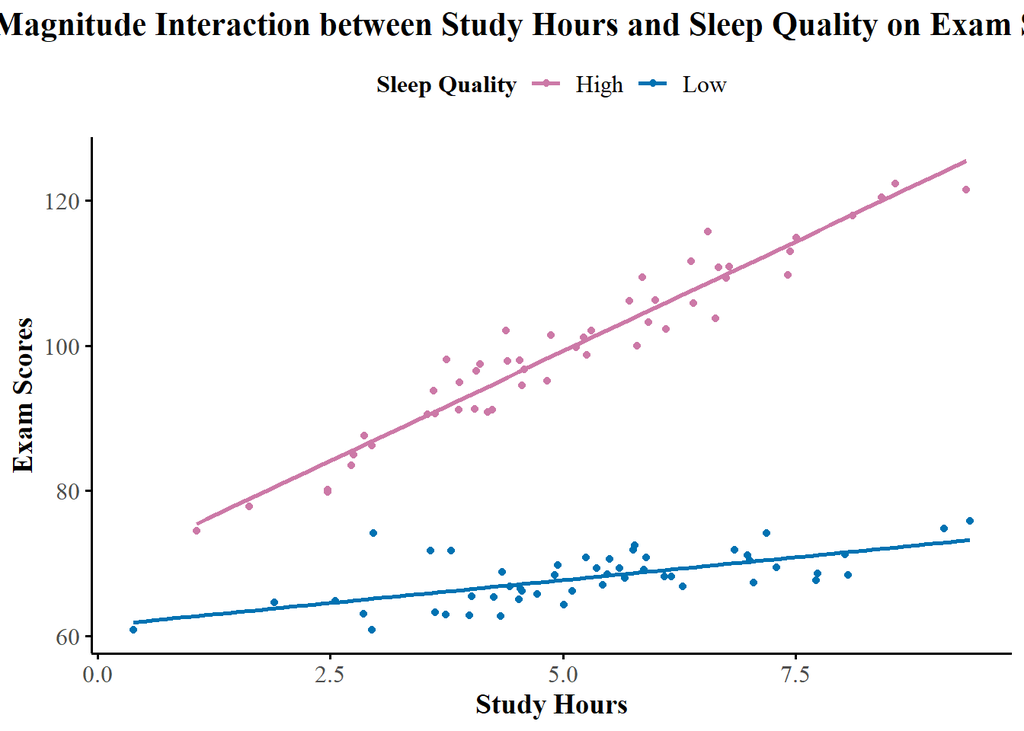

### 2. Simulating a Cross-Over Interaction

In this example, **diet** and **exercise** interact to affect **energy levels** in a way that reverses depending on the level of the other predictor.

```r
# Fit model with interaction term
# diet_code "High"= 1, "Low" = -1
# exercise_code "Intense" = 1, "Light" = -1),
model_crossover <- lm(energy_levels ~ diet_code * exercise_code, data = dataset_crossover)
```

| Diet | Exercise | Mean Energy Levels |
| --- | --- | --- |
| High | Intense | 79.90001 |
| High | Light | 60.30641 |
| Low | Intense | 60.03072 |
| Low | Light | 80.84773 |

Regression Results for Energy Levels Predicted by Diet and Exercise

Energy Levels

Predictors

Estimates

std. Error

Statistic

(Intercept)

70.27 ***

0.28

254.97

Diet Code

-0.17

0.28

-0.61

Exercise Code

-0.31

0.28

-1.11

Diet Code * Exercise Code

10.10 ***

0.28

36.66

Observations

100

R<sup>2</sup> / R<sup>2</sup> adjusted

0.933 / 0.931

- p<0.05 ** p<0.01 *** p<0.001

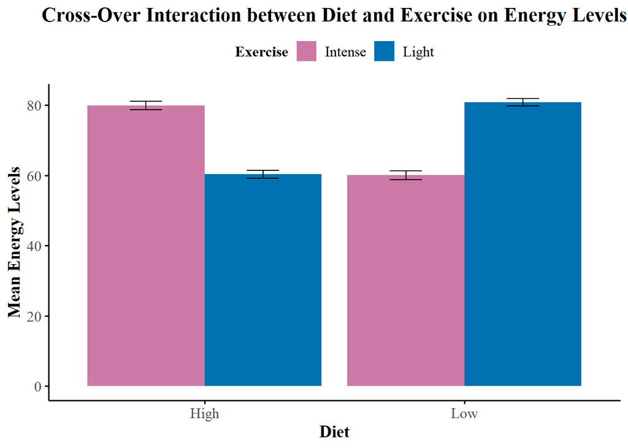

## Running and Visualizing Different Types of Interactions

### Categorical x Categorical Interactions

**Example**: Studying **gender** and **exercise type** on **stress level**.

```r
# Fit model with interaction term
# gender "Male"=  1, "Female" = -1
# exercise_type "Yoga" = 1, "Weightlifting" = -1),

model_cat <- lm(stress_level ~ gender_code * exercise_code, data = dataset_cat)
```

| Gender | Exercise Type | Mean Stress Level |
| --- | --- | --- |
| Male | Yoga | 4.966670 |
| Male | Weightlifting | 9.102137 |
| Female | Yoga | 4.010241 |
| Female | Weightlifting | 6.282576 |

Regression Results for Stress Level Predicted by Gender and Exercise Type

Stress Level

Predictors

Estimates

std. Error

Statistic

(Intercept)

6.09 ***

0.09

66.30

Gender Code

0.94 ***

0.09

10.28

Exercise Code

-1.60 ***

0.09

-17.44

Gender Code * Exercise Code

-0.47 ***

0.09

-5.07

Observations

100

R<sup>2</sup> / R<sup>2</sup> adjusted

0.819 / 0.814

- p<0.05 ** p<0.01 *** p<0.001

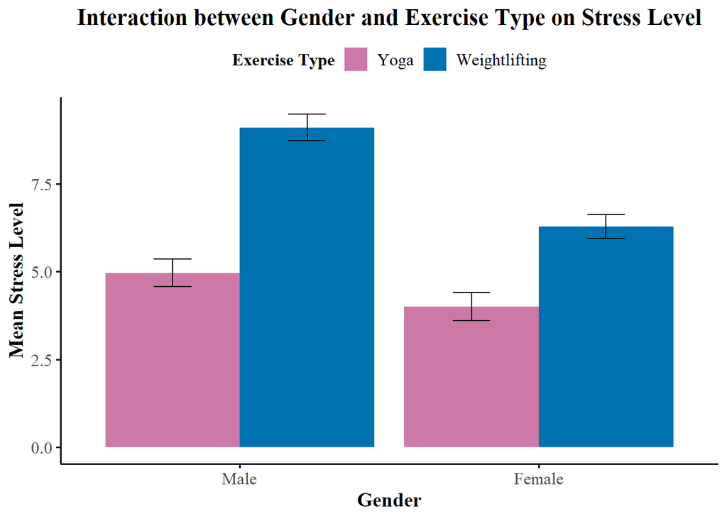

### Linear x Linear Interactions

**Example**: Examining **study hours** and **sleep hours** on **exam scores**.

```r
# Fit the interaction model using continuous variables
model_lin_lin <- lm(exam_scores ~ study_hours * sleep_hours, data = dataset_lin_lin)
```

Regression Results for Exam Scores Predicted by Study Hours and Sleep Hours

Exam Scores

Predictors

Estimates

std. Error

Statistic

(Intercept)

69.48 ***

12.78

5.44

Study Hours

-6.09 *

2.45

-2.49

Sleep Hours

-0.33

1.87

-0.18

Study Hours * Sleep Hours

2.11 ***

0.36

5.81

Observations

100

R<sup>2</sup> / R<sup>2</sup> adjusted

0.843 / 0.838

- p<0.05 ** p<0.01 *** p<0.001

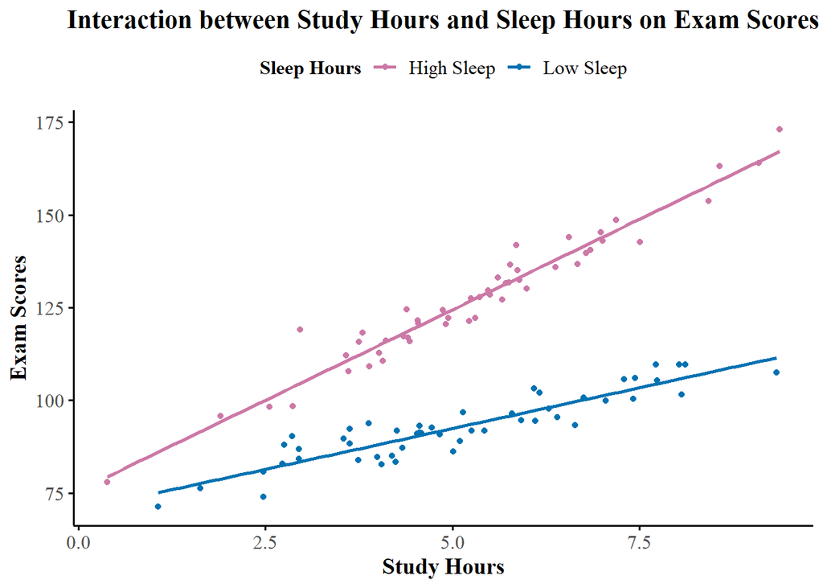

## APA Reporting for Main Effects and Interaction

### Results

A multiple regression analysis was conducted to examine the effects of **Study Hours** and **Sleep Hours** on **Exam Scores** and to test for an interaction between **Study Hours** and **Sleep Hours**. Descriptive statistics for each variable are presented in Table 1.

### Tables and Figure

#### Table 1

Table 1 presents descriptive statistics for the study variables, including means and standard deviations for **Study Hours**, **Sleep Hours**, and **Exam Scores** for the full sample.

[output not shown]

#### Table 2

Table 2 shows the regression coefficients, standard errors, $t$-values, and significance levels for the predictors in the model.

[output not shown]

#### Figure 1

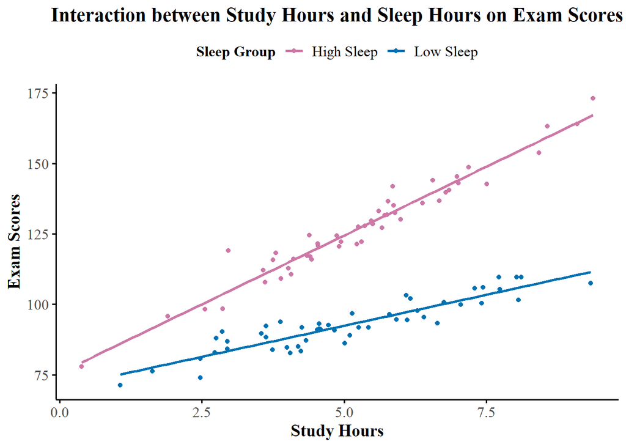

Figure 1 illustrates the interaction effect between **Study Hours** and **Sleep Hours** on **Exam Scores**. Exam scores increase with study hours for both low and high sleep groups; however, the slope is steeper for individuals with high sleep hours, indicating that sleep enhances the effect of study hours on exam performance.

## Summary and Key Takeaways

1. **Main Effects vs. Interactions**:
   - Main effects show isolated impacts, while interactions reveal combined impacts.
2. **Using Means to Detect Interactions**:
   - Comparing group means across predictor levels helps detect interactions.
3. **Real-World Relevance**:
   - Interactions show how combined factors impact outcomes, which is vital in fields like psychology and public health.
4. **Categorical x Categorical, Linear x Linear, and Linear x Categorical**:
   - Use effect coding for categorical predictors in `lm()` models and factors for visualization.
   - Plotting interactions helps reveal patterns such as cross-over or magnitude effects.